# R Notebook

```r
library(tidyverse)
library(CodeClanData)
```

Question 1:

```r
colnames(backpack)
```

```
[1] "backpack_weight" "body_weight"     "ratio"           "back_problems"   "major"
[6] "year"            "sex"             "status"          "units"
```

```r
glimpse(backpack)
```

```
Rows: 100
Columns: 9
$ backpack_weight <int> 9, 8, 10, 6, 8, 5, 8, 4, 5, 2, 8, 21, 11, 11, 12, 11, 13, 6, 10, 5, 20, 14, 11, 1…
$ body_weight     <int> 125, 195, 120, 155, 180, 240, 170, 185, 130, 120, 135, 160, 170, 170, 125, 175, 1…
$ ratio           <dbl> 0.0720000, 0.0410256, 0.0833333, 0.0387097, 0.0444444, 0.0208333, 0.0470588, 0.02…
$ back_problems   <int> 1, 0, 1, 0, 0, 0, 0, 1, 0, 0, 0, 0, 0, 1, 1, 0, 1, 0, 1, 0, 0, 1, 0, 0, 0, 1, 0, …
$ major           <fct> Bio, Philosophy, GRC, CSC, EE, History, CM, ARCE, Bio, Bio, Bus, ME, CPE, CPE, CS…
$ year            <int> 3, 5, 4, 6, 2, 0, 3, 5, 4, 5, 3, 5, 4, 4, 3, 4, 4, 3, 3, 3, 2, 2, 5, 5, 3, 1, 4, …
$ sex             <fct> Female, Male, Female, Male, Female, Male, Male, Female, Female, Female, Female, M…
$ status          <fct> U, U, U, G, U, G, U, U, U, U, U, U, U, U, U, U, U, U, U, U, U, U, U, U, U, U, U, …
$ units           <int> 13, 12, 14, 0, 14, 0, 15, 18, 14, 8, 15, 12, 16, 16, 12, 16, 16, 16, 17, 14, 16, …
```

Question 2 - What is the distribution of backpack weights that students are carrying? Choose an appropriate graph to show the distribution.

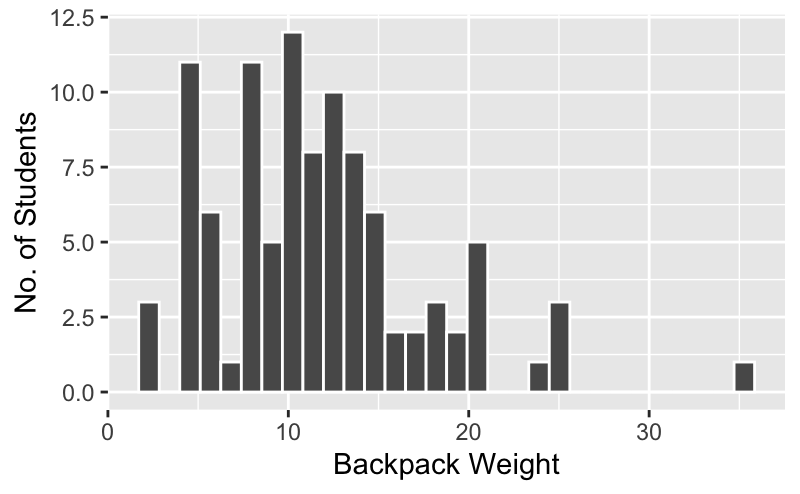

```r
ggplot(backpack) +
  aes(x = backpack_weight) +
  geom_histogram(col = "white") +
  labs(y = "No. of Students",
       x = "Backpack Weight")
```

Question 3 - Are there differences in backpack weight between sex?

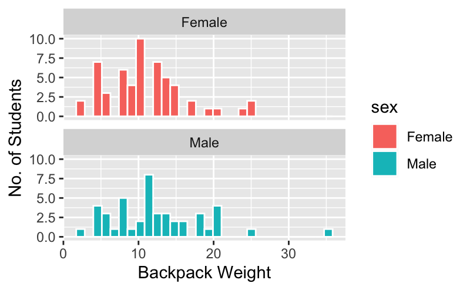

```r
ggplot(backpack) +
  aes(x = backpack_weight, fill = sex) +
  geom_histogram(col = "white") +
  labs(y = "No. of Students",
       x = "Backpack Weight") +
  facet_wrap(~ sex, ncol = 1)
```

As can be seen from above charts, there is no great difference in the distribution of backpack weights when comparing male versus female.

Question 4 - What is the relationship between body weight and backpack weight?

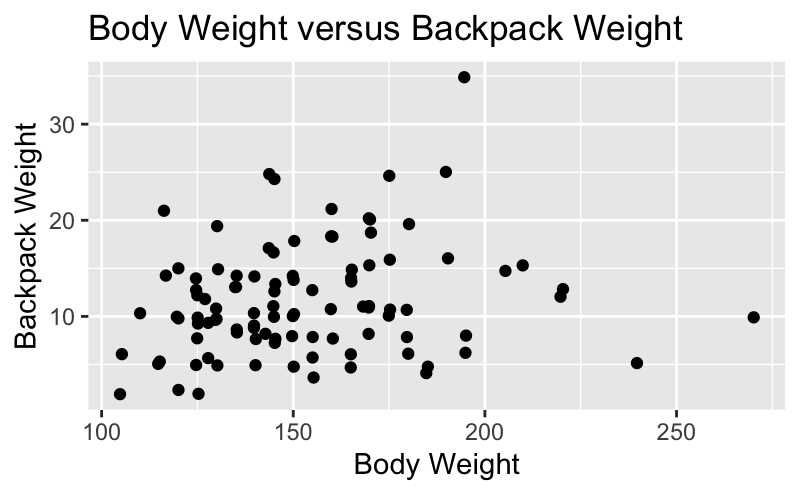

```r
ggplot(backpack) +
  aes(x = body_weight, y = backpack_weight) +
  geom_point(position = "jitter") +
  labs(
    x = "Body Weight",
    y = "Backpack Weight",
    title = "Body Weight versus Backpack Weight"
  )
```

A weak positive relationship with body weight and backpack weight.

Question 5 - Is this relationship different between men and women? Choose an appropriate plot and interpret your findings.

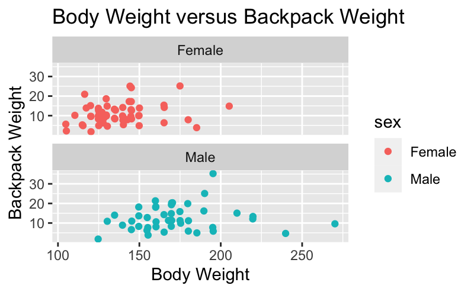

```r
ggplot(backpack) +
  aes(x = body_weight, y = backpack_weight, colour = sex) +
  geom_point(position = "jitter") +
  labs(
    x = "Body Weight",
    y = "Backpack Weight",
    title = "Body Weight versus Backpack Weight"
  )+ facet_wrap( ~ sex, ncol = 1)
```

Strength of relationship looks slightly more positive for women. There is also a difference in the range of bodyweights in women versus men (women have more data points in the lighter bodyweight range).

Question 6 - What proportion of students report back pain?

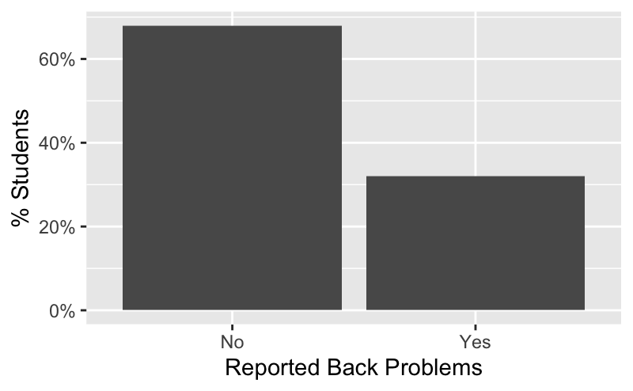

```r
library(scales)

ggplot(backpain, aes(x = factor(back_problems))) +
  geom_bar(aes(y = (..count..)/sum(..count..))) +
  scale_y_continuous(labels = percent) +
  labs(y = "% Students",
       x = "Reported Back Problems")
```

Question 7 - Is this proportion different between men and women?

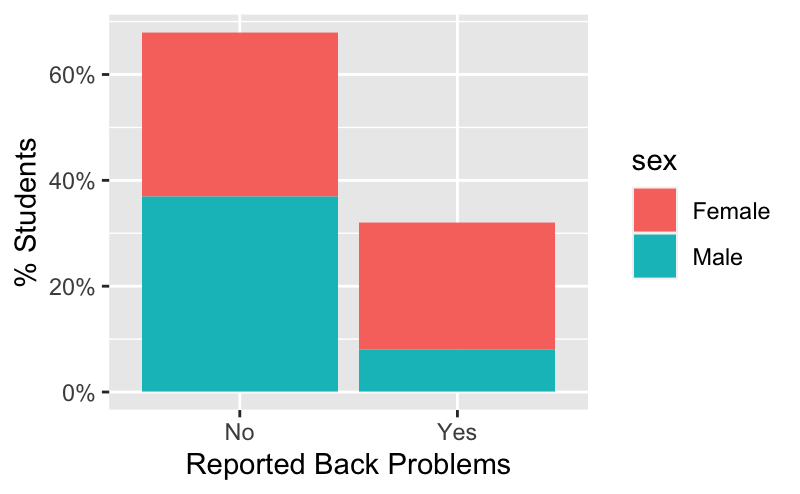

```r
ggplot(backpain, aes(x = factor(back_problems)), position = "fill") +
  geom_bar(aes(y = (..count..)/sum(..count..), fill = sex)) +
  scale_y_continuous(labels = percent) +
  labs(y = "% Students",
       x = "Reported Back Problems")
```

```r
ggplot(backpack, aes(x = factor(back_problems)), position = "fill") +
  geom_bar(aes(y = (..count..)/sum(..count..), fill = sex)) +
  scale_y_continuous(labels = percent) +
  labs(y = "% Students",
       x = "Reported Back Problems") +
  facet_grid(~ body_weight, back_problems)
```

[output not shown]